# Regression Analysis Final Project

### 4 Test for Linearity

One of the key assumptions of multiple linear regression is that there exists a linear relationship between each predictor variable and the response variable.If this assumption is violated, then the results of the regression model can be unreliable. We will check this assumption by creating a partial residual plot, which displays the residuals of one predictor variable against the response variable.

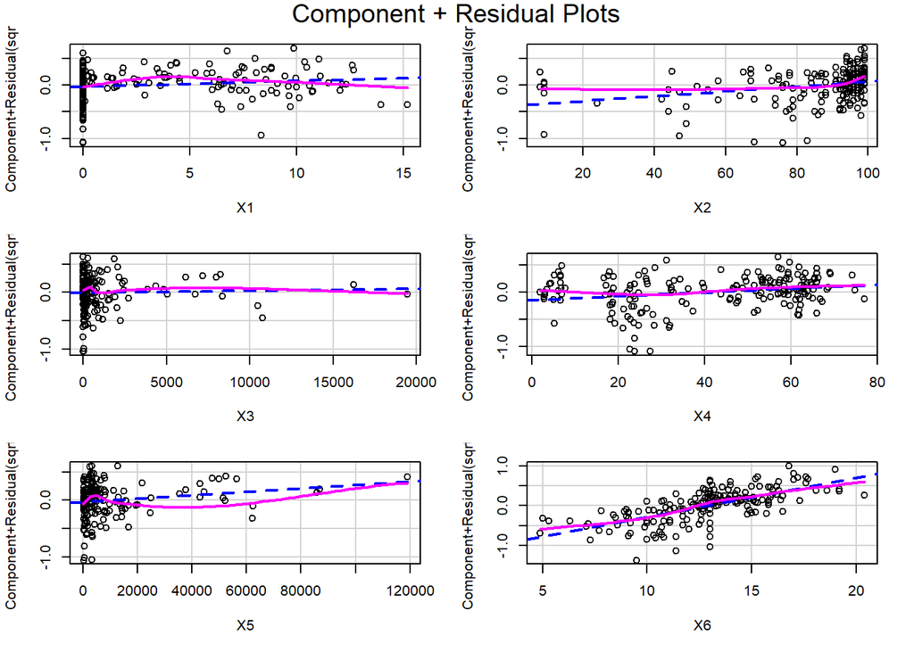

```r
crPlots(modelsqrt)
```

* The blue line shows the expected residuals if the relationship between the predictor and response variable was linear. The pink line shows the actual residuals.If the two lines are significantly different, then this is evidence of a nonlinear relationship.The predictor variables X1,X2 and X5 are fairly non-linear.

- Now we will continue looking for the best fit model and we will use backward elimination using AIC values The backward elimination method starts with a full model that includes all independent variables, and then intaractively removes the least significant variable from the model until the AIC value is minimized. At each step, the AIC value is calculated for the current model, and the variable with the highest p-value (i.e., the least significant variable) is removed from the model. This process is repeated until the AIC value is minimized, indicating the best model fit.

## Step-Wise Regression Transformation

```r
step(model,data=FLED,direction ="backward")
```

```
## Start:  AIC=598.24
## Y ~ X1 + X2 + X3 + X4 + X5 + X6
##
##        Df Sum of Sq    RSS    AIC
## - X3    1      1.34 4457.5 596.29
## - X5    1     20.89 4477.1 597.09
## <none>              4456.2 598.24
## - X1    1     74.72 4530.9 599.28
## - X4    1    197.20 4653.4 604.16
## - X2    1    366.95 4823.1 610.72
## - X6    1   2203.70 6659.9 669.77
##
## Step:  AIC=596.29
## Y ~ X1 + X2 + X4 + X5 + X6
##
##        Df Sum of Sq    RSS    AIC
## <none>              4457.5 596.29
## - X1    1     84.30 4541.8 597.72
## - X5    1    159.32 4616.8 600.72
## - X4    1    196.50 4654.0 602.19
## - X2    1    366.60 4824.1 608.76
## - X6    1   2202.41 6659.9 667.77
```

```
##
## Call:
## lm(formula = Y ~ X1 + X2 + X4 + X5 + X6, data = FLED)
##
## Coefficients:
## (Intercept)           X1           X2           X4           X5           X6
##   4.048e+01    2.016e-01    7.176e-02    5.617e-02    6.069e-05    1.665e+00
```

- Using the backward elimination method we can see that the best fit model is with the independent variables X1,X2,X4,X5 and X6. It has the lowest AIC value of 596.29. We will now fit this model.

### Model1 with Backward Elimination

```r
model1<-lm(Y~X1+X2+X4+X5+X6,FLED)
summary(model1)
```

```
##
## Call:
## lm(formula = Y ~ X1 + X2 + X4 + X5 + X6, data = FLED)
##
## Residuals:
##      Min       1Q   Median       3Q      Max
## -16.5112  -2.7337   0.5397   3.1857  10.9984
##
## Coefficients:
##              Estimate Std. Error t value Pr(>|t|)
## (Intercept) 4.048e+01  2.214e+00  18.286  < 2e-16 ***
## X1          2.016e-01  1.102e-01   1.830 0.068997 .
## X2          7.176e-02  1.881e-02   3.815 0.000188 ***
## X4          5.617e-02  2.011e-02   2.793 0.005792 **
## X5          6.069e-05  2.413e-05   2.515 0.012786 *
## X6          1.665e+00  1.780e-01   9.352  < 2e-16 ***
## ---
## Signif. codes:  0 '***' 0.001 '**' 0.01 '*' 0.05 '.' 0.1 ' ' 1
##
## Residual standard error: 5.018 on 177 degrees of freedom
## Multiple R-squared:  0.6658, Adjusted R-squared:  0.6564
## F-statistic: 70.53 on 5 and 177 DF,  p-value: < 2.2e-16
```

Model Equation: $\hat {Y}= (4.048e+01) + (2.016e-01) \hspace{0.1 cm} X1 + (7.176e-02) \hspace{0.1 cm} X2 + (5.617e-02) \hspace{0.1 cm} X4 + (6.069e-05) \hspace{0.1 cm} X5 + (1.665e+00) \hspace{0.1 cm} X6$

- We can see that there is not much improvement in the R-Squared value, in the original model 66.59% of capability was explained by the model and in this model 66.58% of the variability in data is explained.

We will check whether this new model has violated any assumptions

### Residual Analysis

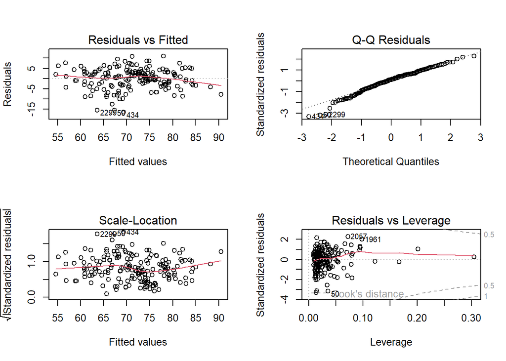

```r
par(mfrow=c(2,2))
plot(model1)
```

### *1 Non-constant error variance test*

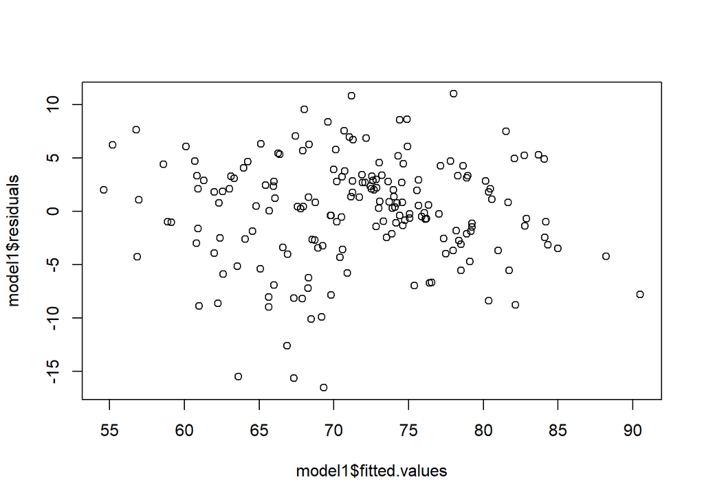

```r
plot(model1$fitted.values, model1$residuals)
```

```r
ncvTest(model1)
```

```
## Non-constant Variance Score Test
## Variance formula: ~ fitted.values
## Chisquare = 3.071089, Df = 1, p = 0.079696
```

- Here,H0: Errors have constant variance and HA: Errors have a non-constant variance.
- The p-value is greater than 0.05 hence we do not reject the null hypothesis. This indicates that the constant error variance assumption is not violated.

### *2 Test for Normally Distributed Errors*

```r
shapiro.test(model1$residuals)
```

```
##
##  Shapiro-Wilk normality test
##
## data:  model1$residuals
## W = 0.97508, p-value = 0.002323
```

- Here, $H0$: Errors are normally distributed and $HA$: Errors are not normally distributed
- The p-value of 0.002323 is less than $0.05$ hence we reject the null hypothesis. This indicates that the normality error assumption is violated.

### *3 Test for Autocorrelated Errors*

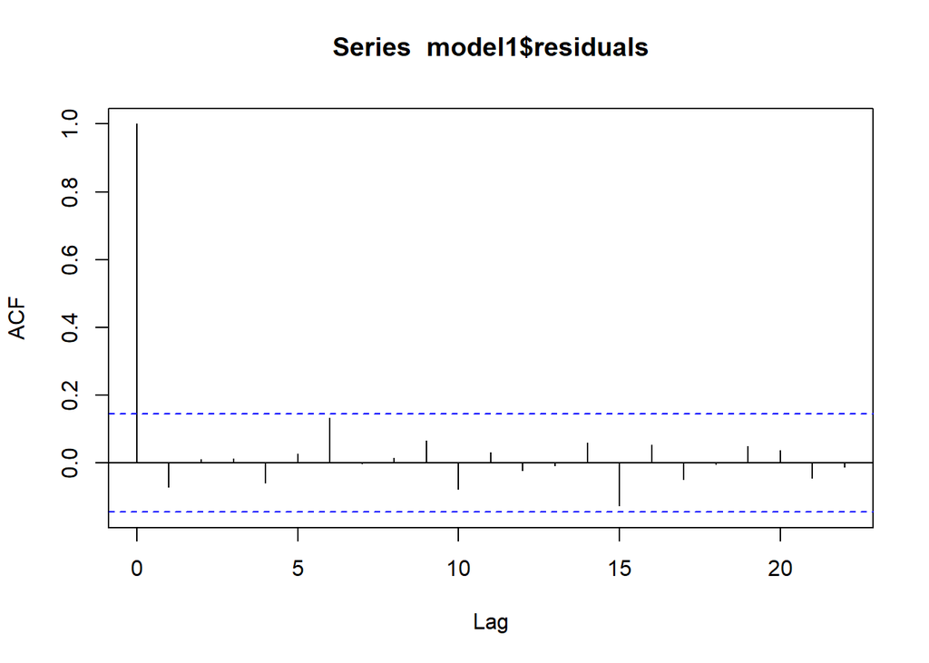

```r
acf(model1$residuals)
```

```r
durbinWatsonTest(model1)
```

```
##  lag Autocorrelation D-W Statistic p-value
##    1     -0.07177861      2.127432   0.384
##  Alternative hypothesis: rho != 0
```

- Here $H0$: Errors are uncorrelated and $HA$: Errors are correlated
- The p-value is greater than $0.05$ hence we do not reject the null hypothesis. This indicates that the uncorrelated error assumption is not violated

### *4 Test for Linearity*

One of the key assumptions of multiple linear regression is that there exists a linear relationship between each predictor variable and the response variable. If this assumption is violated, then the results of the regression model can be unreliable. We will check this assumption by creating a partial residual plot, which displays the residuals of one predictor variable against the response variable.

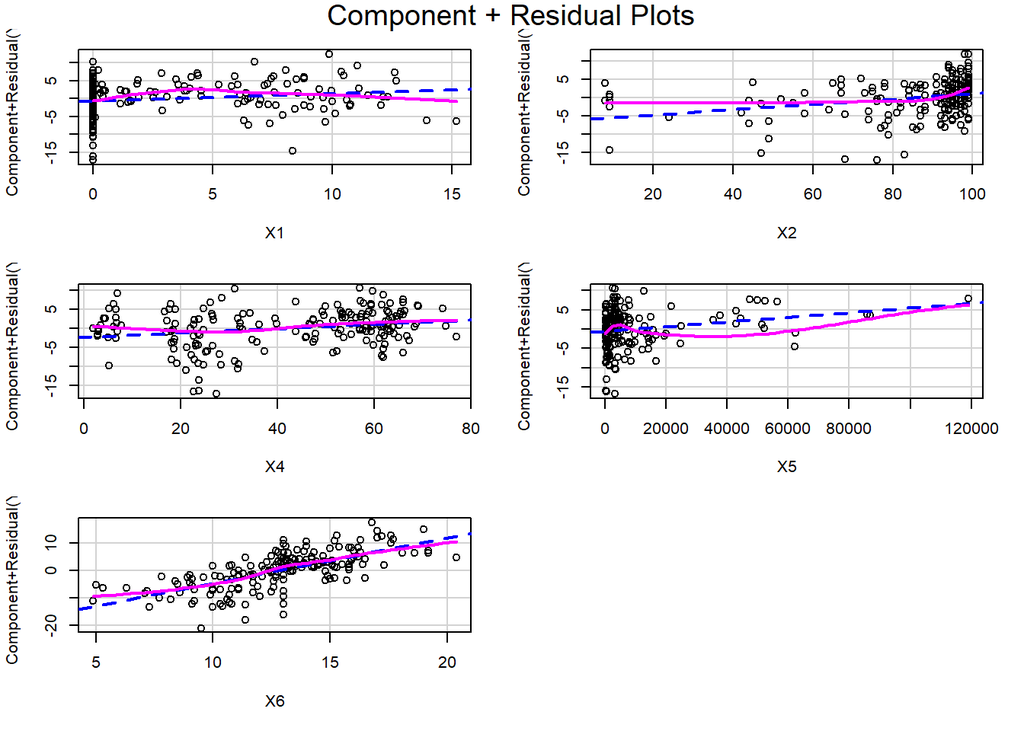

```r
crPlots(model1)
```

- The blue line shows the expected residuals if the relationship between the predictor and response variable was linear. The pink line shows the actual residuals.If the two lines are significantly different, then this is evidence of a nonlinear relationship.The predictor variables X1,X2 and X5 are fairly non-linear.

### *Forward Selection using AIC values*

This is a null model that does not contain any variable only the intercept.

```r
null=lm(Y~1,data = FLED)
```

*The forward selection method starts with a model that includes only a constant term, and then iteractively adds the most significant variable to the model at each step until the AIC value is minimized. At each step, the AIC value is calculated for the current model, and the variable with the highest reduction in AIC value (i.e., the most significant variable) is added to the model. This process is repeated until the AIC value is minimized, indicating the best model fit.

```r
step(null,direction = "forward",data=FLED,scope=list(lower=null, upper=model))
```

```
## Start:  AIC=786.87
## Y ~ 1
##
##        Df Sum of Sq     RSS    AIC
## + X6    1    7955.0  5383.3 622.83
## + X1    1    3684.5  9653.9 729.71
## + X4    1    2967.2 10371.2 742.83
## + X5    1    2535.5 10802.9 750.29
## + X2    1    2212.5 11125.9 755.68
## + X3    1    2121.8 11216.6 757.17
## <none>              13338.4 786.87
##
## Step:  AIC=622.83
## Y ~ X6
##
##        Df Sum of Sq    RSS    AIC
## + X2    1    393.71 4989.6 610.93
## + X4    1    279.40 5103.9 615.08
## + X1    1    192.59 5190.7 618.16
## + X5    1    191.38 5192.0 618.20
## + X3    1    147.83 5235.5 619.73
## <none>              5383.3 622.83
##
## Step:  AIC=610.93
## Y ~ X6 + X2
##
##        Df Sum of Sq    RSS    AIC
## + X4    1    251.91 4737.7 603.45
## + X5    1    193.01 4796.6 605.71
## + X1    1    186.96 4802.7 605.94
## + X3    1    174.96 4814.7 606.40
## <none>              4989.6 610.93
##
## Step:  AIC=603.45
## Y ~ X6 + X2 + X4
##
##        Df Sum of Sq    RSS    AIC
## + X3    1    196.09 4541.6 597.72
## + X5    1    195.90 4541.8 597.72
## + X1    1    120.88 4616.8 600.72
## <none>              4737.7 603.45
##
## Step:  AIC=597.72
## Y ~ X6 + X2 + X4 + X3
##
##        Df Sum of Sq    RSS    AIC
## + X1    1    64.570 4477.1 597.09
## <none>              4541.6 597.72
## + X5    1    10.742 4530.9 599.28
##
## Step:  AIC=597.09
## Y ~ X6 + X2 + X4 + X3 + X1
##
##        Df Sum of Sq    RSS    AIC
## <none>              4477.1 597.09
## + X5    1    20.889 4456.2 598.24
```

```
##
## Call:
## lm(formula = Y ~ X6 + X2 + X4 + X3 + X1, data = FLED)
##
## Coefficients:
## (Intercept)           X6           X2           X4           X3           X1
##   4.010e+01    1.690e+00    7.396e-02    5.887e-02    3.838e-04    1.795e-01
```

- Using forward selection with AIC we can see that the best model is with the independent variables X1, X2,X3,X4 and X6.

### Model2 with Forward Selection

```r
model2<-lm(Y~X1+X2+X3+X4+X6,FLED)
summary(model2)
```

```
##
## Call:
## lm(formula = Y ~ X1 + X2 + X3 + X4 + X6, data = FLED)
##
## Residuals:
##     Min      1Q  Median      3Q     Max
## -16.498  -2.784   0.612   3.133  10.986
##
## Coefficients:
##              Estimate Std. Error t value Pr(>|t|)
## (Intercept) 4.010e+01  2.194e+00  18.274  < 2e-16 ***
## X1          1.795e-01  1.123e-01   1.598 0.111885
## X2          7.396e-02  1.887e-02   3.918 0.000127 ***
## X3          3.838e-04  1.633e-04   2.351 0.019837 *
## X4          5.887e-02  2.022e-02   2.911 0.004070 **
## X6          1.690e+00  1.765e-01   9.573  < 2e-16 ***
## ---
## Signif. codes:  0 '***' 0.001 '**' 0.01 '*' 0.05 '.' 0.1 ' ' 1
##
## Residual standard error: 5.029 on 177 degrees of freedom
## Multiple R-squared:  0.6643, Adjusted R-squared:  0.6549
## F-statistic: 70.07 on 5 and 177 DF,  p-value: < 2.2e-16
```

Model Equation: $\hat {Y}= (4.010e+01) + (1.795e-01) \hspace{0.1 cm} X1 + (7.396e-02) \hspace{0.1 cm} X2 + (3.838e-04) \hspace{0.1 cm} X3 + (5.887e-02) \hspace{0.1 cm} X4 + (1.690e+00) \hspace{0.1 cm} X6$

- Using forward selection with AIC we can see that the best model is with the independent variables X1, X2,X3,X4 and X6.
- From the summary it is evident that 66.43% of the variability in the data is explained by the model and the adjusted R-Squared value is 0.6549.

We will now check if any assumptions have been violated or not.

### Residual Analysis

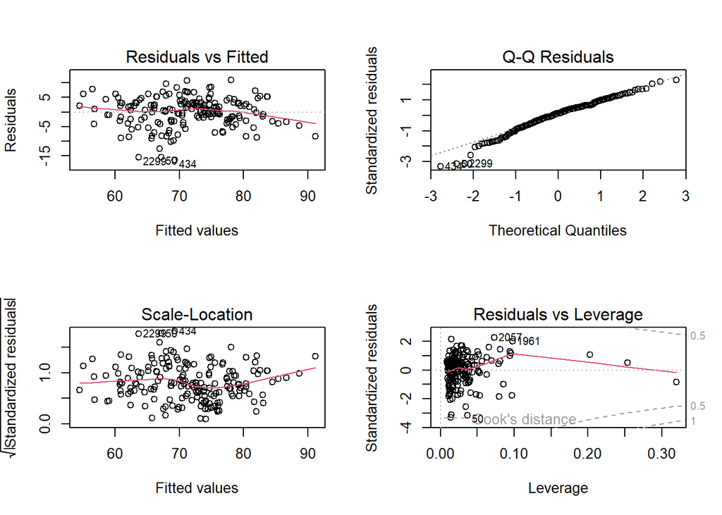

```r
par(mfrow=c(2,2))
plot(model2)
```

### *1 Non-constant error variance test*

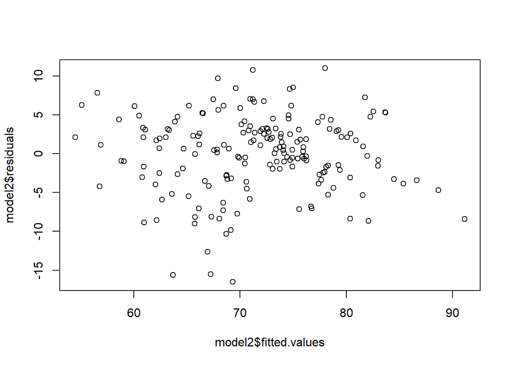

```r
plot(model2$fitted.values, model2$residuals)
```

```r
ncvTest(model2)
```

```
## Non-constant Variance Score Test
## Variance formula: ~ fitted.values
## Chisquare = 2.722392, Df = 1, p = 0.09895
```

- Here, $H0$ Errors have constant variance and $HA$: Errors have a non-constant variance
- The p-value of 0.09895 is greater than 0.05 hence we do not reject the null hypothesis. This indicates that the constant error variance assumption is not violated.

### *2 Test for Normally Distributed Errors*

```r
shapiro.test(model2$residuals)
```

```
##
##  Shapiro-Wilk normality test
##
## data:  model2$residuals
## W = 0.97308, p-value = 0.001316
```

- Here, $H0$: Errors are normally distributed $HA$: Errors are not normally distributed.
- The p-value of 0.001316 is less than 0.05 hence we have enough evidence to reject the null hypothesis. This indicates that the normality error assumption is violated.

### *3 Test for Autocorrelated Errors*

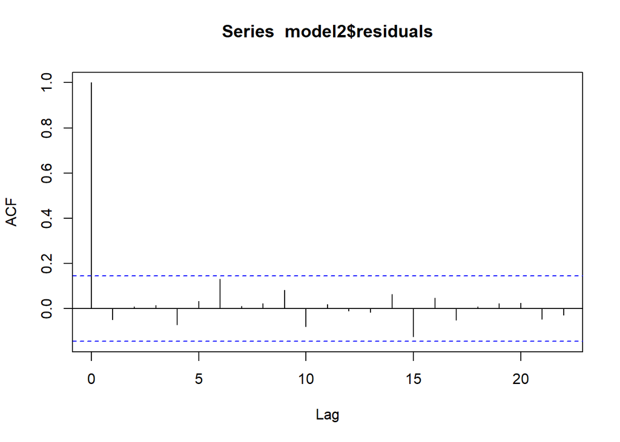

```r
acf(model2$residuals)
```

```r
durbinWatsonTest(model2)
```

```
##  lag Autocorrelation D-W Statistic p-value
##    1     -0.04912785      2.082132   0.572
##  Alternative hypothesis: rho != 0
```

- Here, $H0$ = Errors are uncorrelated and $HA$ = Errors are correlated.
- The p-value is greater than 0.05 hence we do not reject the $H0$. This indicates that the uncorrelated error assumption is not violated.

### *4 Test for Linearity*

One of the key assumptions of multiple linear regression is that there exists a linear relationship between each predictor variable and the response variable. If this assumption is violated, then the results of the regression model can be unreliable. We will check this assumption by creating a partial residual plot, which displays the residuals of one predictor variable against the response variable.

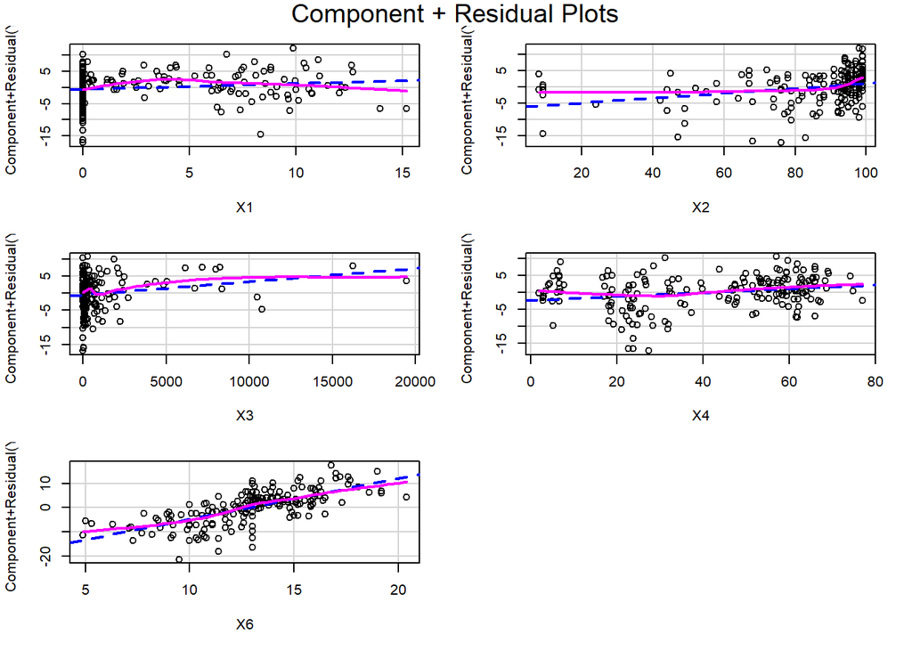

```r
crPlots(model2)
```

* The blue line shows the expected residuals if the relationship between the predictor and response variable was linear. The pink line shows the actual residuals.If the two lines are significantly different, then this is evidence of a nonlinear relationship.

- The predictor variables X1,X2 and X3 are fairly non-linear.

### *Stepwise regression using AIC values*

```r
step(null, scope = list(upper=model), data=FLED, direction="both")
```

```
## Start:  AIC=786.87
## Y ~ 1
##
##        Df Sum of Sq     RSS    AIC
## + X6    1    7955.0  5383.3 622.83
## + X1    1    3684.5  9653.9 729.71
## + X4    1    2967.2 10371.2 742.83
## + X5    1    2535.5 10802.9 750.29
## + X2    1    2212.5 11125.9 755.68
## + X3    1    2121.8 11216.6 757.17
## <none>              13338.4 786.87
##
## Step:  AIC=622.83
## Y ~ X6
##
##        Df Sum of Sq     RSS    AIC
## + X2    1     393.7  4989.6 610.93
## + X4    1     279.4  5103.9 615.08
## + X1    1     192.6  5190.7 618.16
## + X5    1     191.4  5192.0 618.20
## + X3    1     147.8  5235.5 619.73
## <none>               5383.3 622.83
## - X6    1    7955.0 13338.4 786.87
##
## Step:  AIC=610.93
## Y ~ X6 + X2
##
##        Df Sum of Sq     RSS    AIC
## + X4    1     251.9  4737.7 603.45
## + X5    1     193.0  4796.6 605.71
## + X1    1     187.0  4802.7 605.94
## + X3    1     175.0  4814.7 606.40
## <none>               4989.6 610.93
## - X2    1     393.7  5383.3 622.83
## - X6    1    6136.3 11125.9 755.68
##
## Step:  AIC=603.45
## Y ~ X6 + X2 + X4
##
##        Df Sum of Sq    RSS    AIC
```

[output cut: 16 more lines]

```
## - X4    1    273.04 4814.7 606.40
## - X2    1    393.00 4934.6 610.90
## - X6    1   3003.39 7545.0 688.61
##
## Step:  AIC=597.09
## Y ~ X6 + X2 + X4 + X3 + X1
##
##        Df Sum of Sq    RSS    AIC
## <none>              4477.1 597.09
## - X1    1     64.57 4541.6 597.72
## + X5    1     20.89 4456.2 598.24
## - X3    1    139.78 4616.8 600.72
## - X4    1    214.30 4691.4 603.65
## - X2    1    388.33 4865.4 610.32
## - X6    1   2318.16 6795.2 671.45
```

```
##
## Call:
## lm(formula = Y ~ X6 + X2 + X4 + X3 + X1, data = FLED)
##
## Coefficients:
## (Intercept)           X6           X2           X4           X3           X1
##   4.010e+01    1.690e+00    7.396e-02    5.887e-02    3.838e-04    1.795e-01
```

- Stepwise regression gives us the same result as forward selection using AIC values.
- Based on all models considered model, modellog, model1 and model2. Model1 is the best.

## *Conclusion*

We have successfully analyzed the data provided by checking the multicollinearity among the six variables which we have considered. The plot for the data is plotted and we did the residual analysis for the same. To the model, we have performed log transformation, square root transformation and stepwise regression with backward elimination and forward selection. Whilst the transformation, we have performed the residual analysis as well. Further, we did the test for Error variance, Normally Distributed Errors, Error Autocorrelation and Test for Linearity.